# Kaggle: New York Stock Exchange

Bryant Mondragon

November 24, 2018

### Introduction to data

Content Dataset consists of following files:

These are the SEC (Securities & Exchange) 10k annual fillings (2012-2016)

prices.csv: raw, as-is daily prices. Most of data spans from 2010 to the end 2016, for companies new on stock market date range is shorter. There have been approx. 140 stock splits in that time, this set doesn’t account for that.

prices-split-adjusted.csv: same as prices, but there have been added adjustments for splits.

securities.csv: general description of each company with division on sectors

Acknowledgements Prices were fetched from Yahoo Finance, fundamentals are from Nasdaq Financials, extended by some fields from EDGAR SEC databases.

```r
library(quantmod)
library(dplyr)
```

```r
library(ggplot2)
library(Quandl)
nyse<-read.table("C:\\Users\\Bryant\\Documents\\VSCode\\R\\project\\nyse\\prices.csv",header = TRUE,sep=",")
securities <- read.table("C:\\Users\\Bryant\\Documents\\VSCode\\R\\project\\nyse\\securities.csv",header = TRUE,sep=",")
```

Lets Find the structure of the Stock Table!

```r
head(nyse)
```

```
##                  date symbol   open  close    low   high  volume
## 1 2016-01-05 00:00:00   WLTW 123.43 125.84 122.31 126.25 2163600
## 2 2016-01-06 00:00:00   WLTW 125.24 119.98 119.94 125.54 2386400
## 3 2016-01-07 00:00:00   WLTW 116.38 114.95 114.93 119.74 2489500
## 4 2016-01-08 00:00:00   WLTW 115.48 116.62 113.50 117.44 2006300
## 5 2016-01-11 00:00:00   WLTW 117.01 114.97 114.09 117.33 1408600
## 6 2016-01-12 00:00:00   WLTW 115.51 115.55 114.50 116.06 1098000
```

```r
unique(nyse$symbol)
```

```
##   [1] WLTW  A     AAL   AAP   AAPL  ABC   ABT   ACN   ADBE  ADI   ADM
##  [12] ADP   ADS   ADSK  AEE   AEP   AES   AET   AFL   AGN   AIG   AIZ
##  [23] AJG   AKAM  ALB   ALK   ALL   ALXN  AMAT  AME   AMG   AMGN  AMP
##  [34] AMT   AMZN  AN    ANTM  AON   APA   APC   APD   APH   ARNC  ATVI
##  [45] AVB   AVGO  AVY   AWK   AXP   AYI   AZO   BA    BAC   BAX   BBBY
##  [56] BBT   BBY   BCR   BDX   BEN   BHI   BIIB  BK    BLK   BLL   BMY
##  [67] BSX   BWA   BXP   C     CA    CAG   CAH   CAT   CB    CBG   CBS
##  [78] CCI   CCL   CELG  CERN  CF    CHD   CHK   CHRW  CI    CINF  CL
##  [89] CLX   CMA   CMCSA CME   CMG   CMI   CMS   CNC   CNP   COF   COG
## [100] COH   COL   COO   COP   COST  CPB   CRM   CSCO  CSX   CTAS  CTL
## [111] CTSH  CTXS  CVS   CVX   CXO   D     DAL   DD    DE    DFS   DG
## [122] DGX   DHI   DHR   DIS   DISCA DISCK DLR   DLTR  DNB   DOV   DOW
## [133] DPS   DRI   DTE   DUK   DVA   DVN   EA    EBAY  ECL   ED    EFX
## [144] EIX   EL    EMN   EMR   ENDP  EOG   EQIX  EQR   EQT   ES    ESRX
## [155] ESS   ETFC  ETN   ETR   EW    EXC   EXPD  EXPE  EXR   F     FAST
```

[output cut: 32 more lines]

```r
# Here we extract the data for Google
google <- subset(nyse,symbol=="GOOG")
google[1:3,]
```

```
##            date symbol     open    close      low     high  volume
## 440  2010-01-04   GOOG 626.9511 626.7511 624.2411 629.5111 3927000
## 908  2010-01-05   GOOG 627.1811 623.9911 621.5410 627.8411 6031900
## 1376 2010-01-06   GOOG 625.8611 608.2610 606.3610 625.8611 7987100
```

```r
# We then create a vector called close in order to give a better way to graph.
close <- google$close
close[1:3]
```

```
## [1] 626.7511 623.9911 608.2610
```

Time to plot:

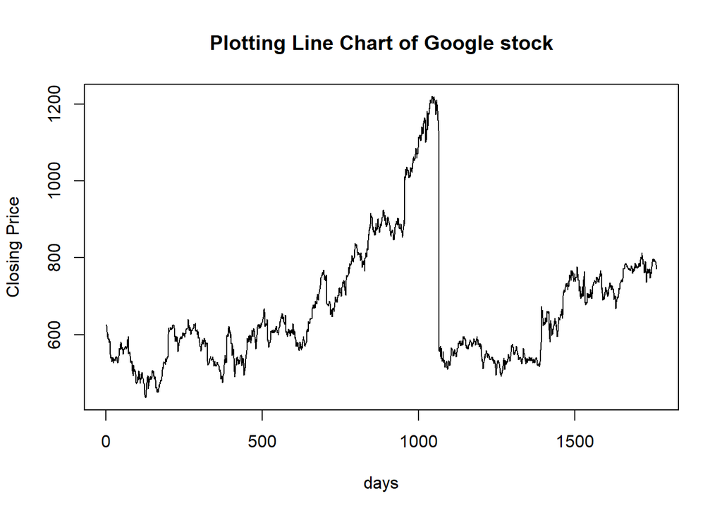

```r
#Line Graph
plot(close, type="l",xlab = "days",ylab = "Closing Price",main="Plotting Line Chart of Google stock")
```

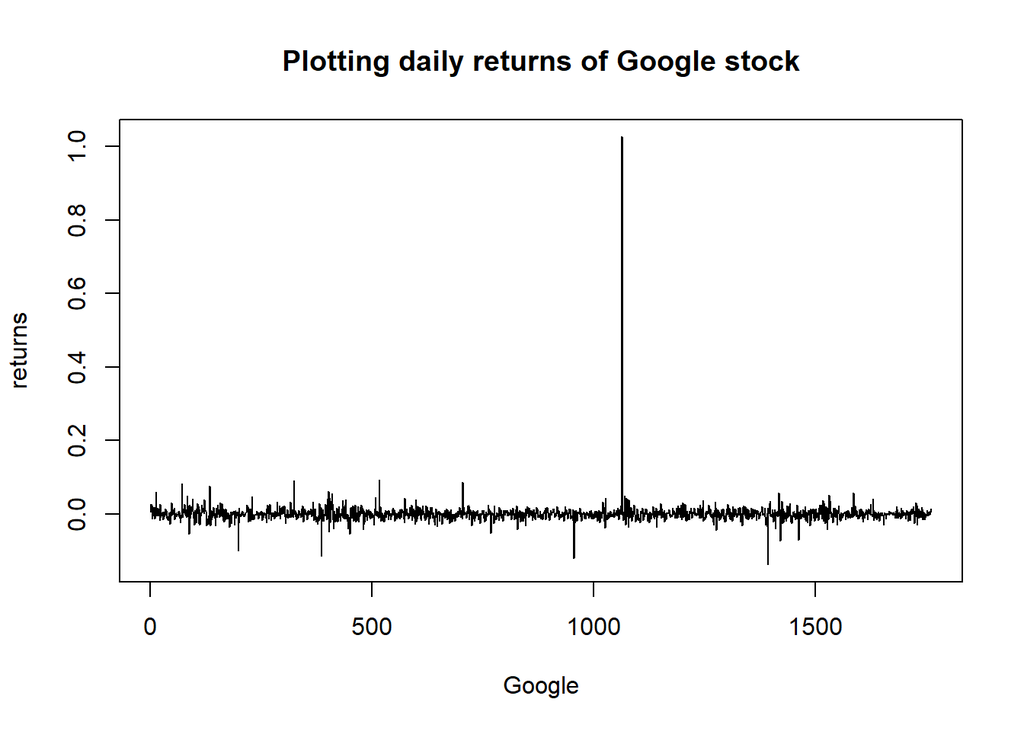

```r
#Calculating Arthmatic daily return
returns<-(close[1:(length(close)-1)]-close[2:length(close)])/close[2:length(close)]

#Plot Daily return into a chart
plot(returns,type = "l",xlab = "Google",main="Plotting daily returns of Google stock")
```

```r
#Creating a OHLC from the excel data to create a candlestick chart.
ohlc<-google[c("date","open","high","low","close","volume")]
head(ohlc)
```

```
##            date     open     high      low    close   volume
## 440  2010-01-04 626.9511 629.5111 624.2411 626.7511  3927000
## 908  2010-01-05 627.1811 627.8411 621.5410 623.9911  6031900
## 1376 2010-01-06 625.8611 625.8611 606.3610 608.2610  7987100
## 1844 2010-01-07 609.4010 610.0010 592.6510 594.1010 12876600
## 2312 2010-01-08 592.0010 603.2510 589.1110 602.0210  9483900
## 2780 2010-01-11 604.4611 604.4611 594.0410 601.1110 14479800
```

Lets try another Company, IBM.

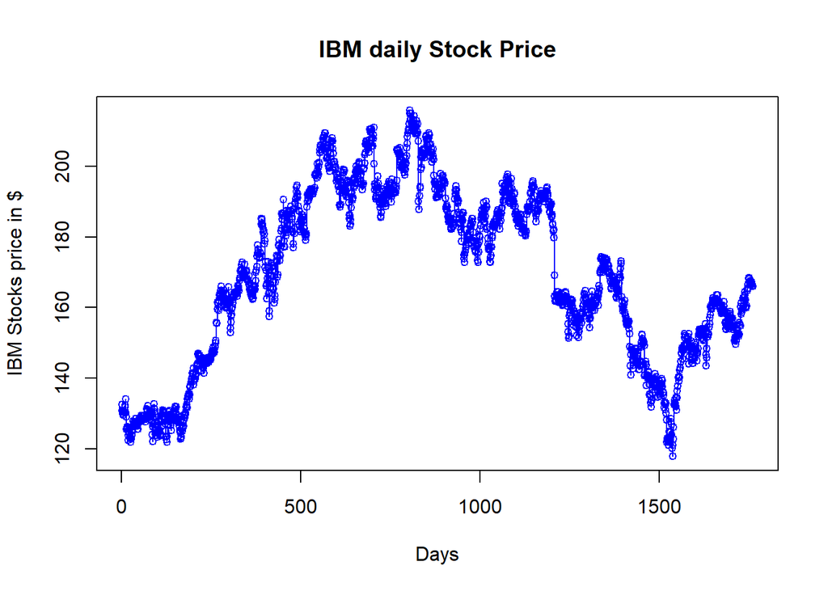

```r
ibmstock <- subset(nyse, symbol =='IBM')


#Lets Plot the IBM Daily Stock Price
plot.ts(ibmstock$close, col="blue", type="o", ylab = "IBM Stocks price in $",
        xlab = "Days", main = "IBM daily Stock Price",  cex = .8)
```

We can do some other cool things such as getting the summary for the entire dataset which is pretty neat.

```r
summary(nyse)
```

```
##          date            symbol            open             close
##  2015-11-16:   498   A      :  1762   Min.   :   0.85   Min.   :   0.86
##  2015-11-17:   498   AAL    :  1762   1st Qu.:  33.84   1st Qu.:  33.85
##  2015-11-18:   498   AAP    :  1762   Median :  52.77   Median :  52.80
##  2015-11-19:   498   AAPL   :  1762   Mean   :  70.84   Mean   :  70.86
##  2015-11-20:   498   ABC    :  1762   3rd Qu.:  79.88   3rd Qu.:  79.89
##  2015-11-23:   498   ABT    :  1762   Max.   :1584.44   Max.   :1578.13
##  (Other)   :848276   (Other):840692
##       low               high             volume
##  Min.   :   0.83   Min.   :   0.88   Min.   :        0
##  1st Qu.:  33.48   1st Qu.:  34.19   1st Qu.:  1221500
##  Median :  52.23   Median :  53.31   Median :  2476250
##  Mean   :  70.12   Mean   :  71.54   Mean   :  5415113
##  3rd Qu.:  79.11   3rd Qu.:  80.61   3rd Qu.:  5222500
##  Max.   :1549.94   Max.   :1600.93   Max.   :859643400
##
```

```r
summary(nyse$open)
```

```
##    Min. 1st Qu.  Median    Mean 3rd Qu.    Max.
##    0.85   33.84   52.77   70.84   79.88 1584.44
```

```r
summary(nyse$close)
```

```
##    Min. 1st Qu.  Median    Mean 3rd Qu.    Max.
##    0.86   33.85   52.80   70.86   79.89 1578.13
```

### Conclusions

In conclusion this is also a pretty powerful dataset to analyze. With a bit more time and domain knowledge you could do lots of things such as maybe attempting to do one day ahead predictions by using things such as Linear Regression and Neural Networks; you can also try to figure out which company has the biggest chance of being backrupt, which ones is/are undervalued and much more. This dataset gives us alot of information on each of the companies which we could also use to track any major changes and possible link them to events in the real world which could have made a significant impact.